# Exam 1

## Exam 1

#### Question

1. La tabla muestra el registro semanal que lleva una persona de los gastos relacionados con su carro.

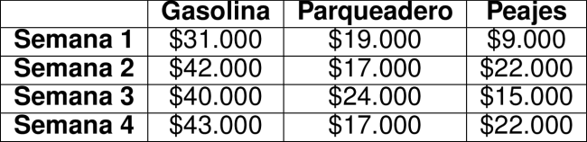

   Si la persona quiere realizar una comparación detallada entre los gastos de cada categoría (gasolina, parqueadero, peajes) a lo largo de las diferentes semanas, ¿cuál de las siguientes gráficas le permite hacer esto directamente?

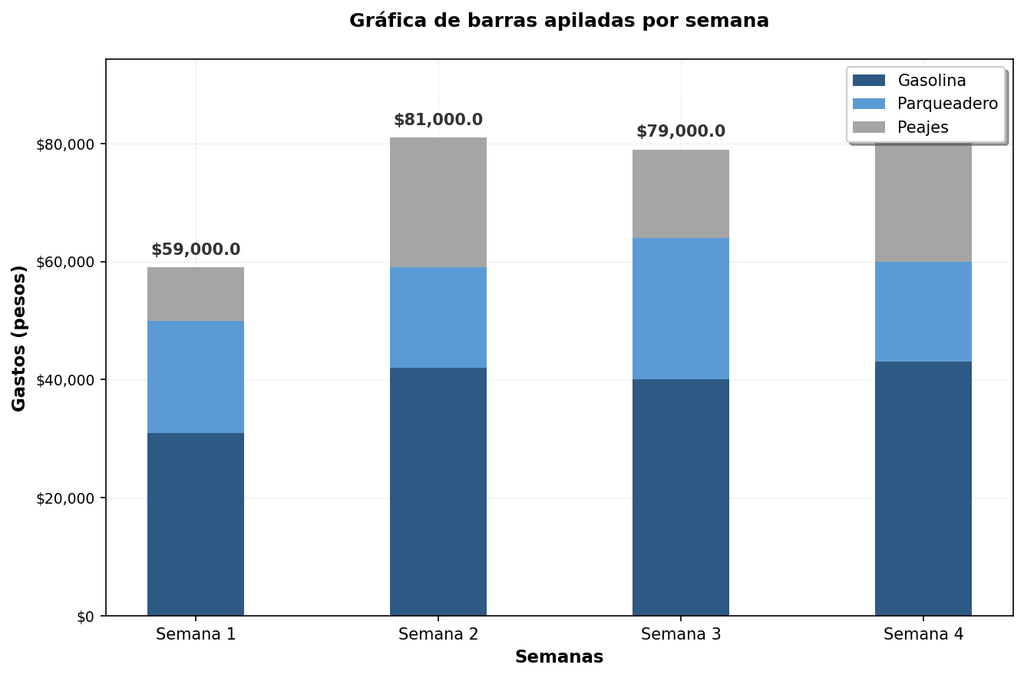

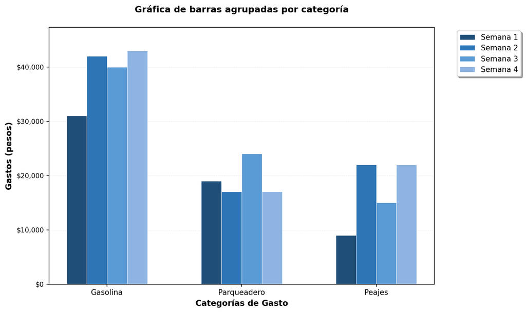

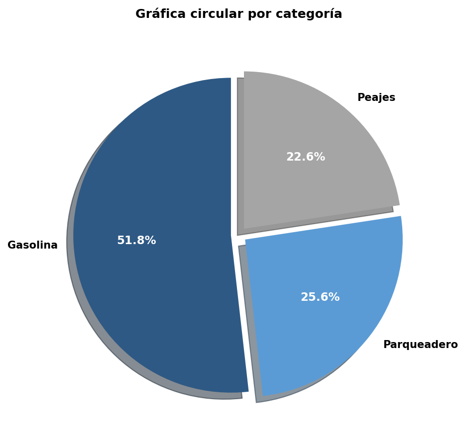

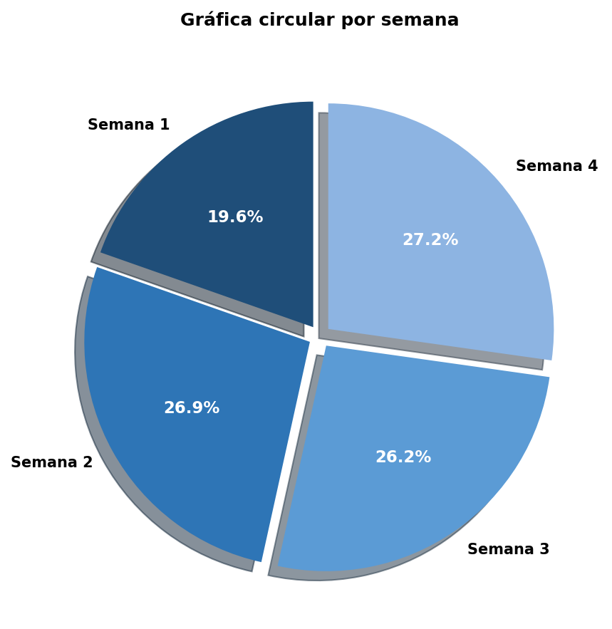

#### Solution

   Para resolver este problema, necesitamos identificar qué tipo de gráfica permite comparar directamente los **gastos de cada categoría a lo largo de las diferentes semanas**.

### Análisis de los datos

   Los datos muestran gastos por categoría en cada semana:
   - **Gasolina:** Semana 1: $31.000, Semana 2: $42.000, Semana 3: $40.000, Semana 4: $43.000
   - **Parqueadero:** Semana 1: $19.000, Semana 2: $17.000, Semana 3: $24.000, Semana 4: $17.000
   - **Peajes:** Semana 1: $9.000, Semana 2: $22.000, Semana 3: $15.000, Semana 4: $22.000

### Análisis de cada opción

   **Gráfica circular por categoría:**
   - Muestra la proporción de cada tipo de gasto en el total general del mes
   - NO permite ver la evolución de cada categoría por semana

   **Gráfica de barras apiladas por semana:**
   - Cada barra representa una semana con categorías apiladas
   - Dificulta comparar una misma categoría entre diferentes semanas
   - No es óptima para comparaciones detalladas por categoría

   **Gráfica circular por semana:**
   - Muestra la proporción de gastos de cada semana respecto al total del mes
   - No permite comparar categorías específicas entre semanas

   **Gráfica de barras agrupadas por categoría:**
   - Agrupa las barras por tipo de gasto (gasolina, parqueadero, peajes)
   - Cada categoría tiene 4 barras (una por semana) lado a lado
   - Permite comparar directamente cómo varía cada categoría a lo largo de las semanas
   - **Esta es la respuesta correcta**

### Conclusión

   La **Opción “gráfica de barras agrupadas por categoría”** es la única que permite realizar una comparación detallada entre los gastos de cada categoría a lo largo de las diferentes semanas, ya que agrupa las barras por tipo de gasto y muestra claramente la evolución temporal de cada categoría.
   1. Falso
   2. Verdadero
   3. Falso
   4. Falso